# Assignment 1

Subhash Bharadwaj Pemmaraju, Raghu Mohan Sanugommula

30th January 2019

### Introduction: Initial Data Analysis

The data for this analysis consists of universities from 5 states [^1] -

- California (CA)
- Massachusetts (MA)
- New York (NY)
- North Carolina (NC)
- Washington (WA)

An Initial count of universities is made by State and by State and by State and Sector. The sectors have been renamed from coded numbers to descriptions using **factor** command [^2]

```r
sum1%>%kable("html")%>%kable_styling(bootstrap_options="striped",full_width=FALSE)
```

| STABBR | Number_of_Universities |
| --- | --- |
| CA | 100 |
| MA | 68 |
| NC | 55 |
| NY | 133 |
| WA | 19 |

```r
sum2%>%kable("html")%>%kable_styling(bootstrap_options="striped",full_width=FALSE)
```

| STABBR | SECTOR.f | Number_of_Universities |
| --- | --- | --- |
| CA | Public, >=4 yrs | 32 |
| CA | Non-Profit, >=4 yrs | 60 |
| CA | Profit, >=4 yrs | 7 |
| CA | Profit, 2 yrs | 1 |
| MA | Public, >=4 yrs | 13 |
| MA | Non-Profit, >=4 yrs | 54 |
| MA | Profit, >=4 yrs | 1 |
| NC | Public, >=4 yrs | 16 |
| NC | Non-Profit, >=4 yrs | 38 |
| NC | Non-Profit, 2 yrs | 1 |
| NY | Public, >=4 yrs | 39 |
| NY | Non-Profit, >=4 yrs | 87 |
| NY | Profit, >=4 yrs | 3 |
| NY | Non-Profit, 2 yrs | 4 |
| WA | Public, >=4 yrs | 7 |
| WA | Non-Profit, >=4 yrs | 11 |
| WA | Profit, >=4 yrs | 1 |

The formatting of the tables is achieved by using **kable styling** [^3]

As can be seen from the tables, there are is a distinct difference between states on how many universities they have and in different sectors. A **Bar Plot** of the data is made and reveals that New York has the most number of non-profits (87) as can be seen below[^4],[^5],[^6]:

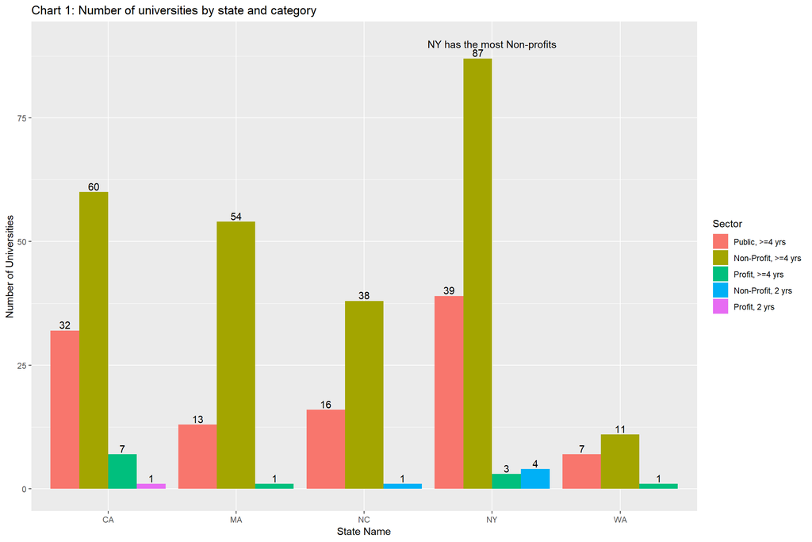

```r
ggplot(sum2, aes(x=STABBR, y=Number_of_Universities, fill=SECTOR.f))+
  geom_bar(aes(fill=SECTOR.f), position = "dodge", stat="identity")+
  ggtitle("Chart 1: Number of universities by state and category")+
  xlab("State Name")+ylab("Number of Universities")+
  geom_text(aes(label = sum2$Number_of_Universities), position=position_dodge(width=0.9), vjust=-0.25)+
  labs(fill="Sector")+
  annotate("text", x = 4, y = 90, label = "NY has the most Non-profits")
```

### Analysis of Salaries

#### Salary Distribution

A chart of the average salaries by state and sector reveals surprisingly that on average public and non-profits with 4 year programs or above have higher salaries than for-profit programs. Furthermore we find that CA and MA in general have the highest salaries for these sectors [^7].

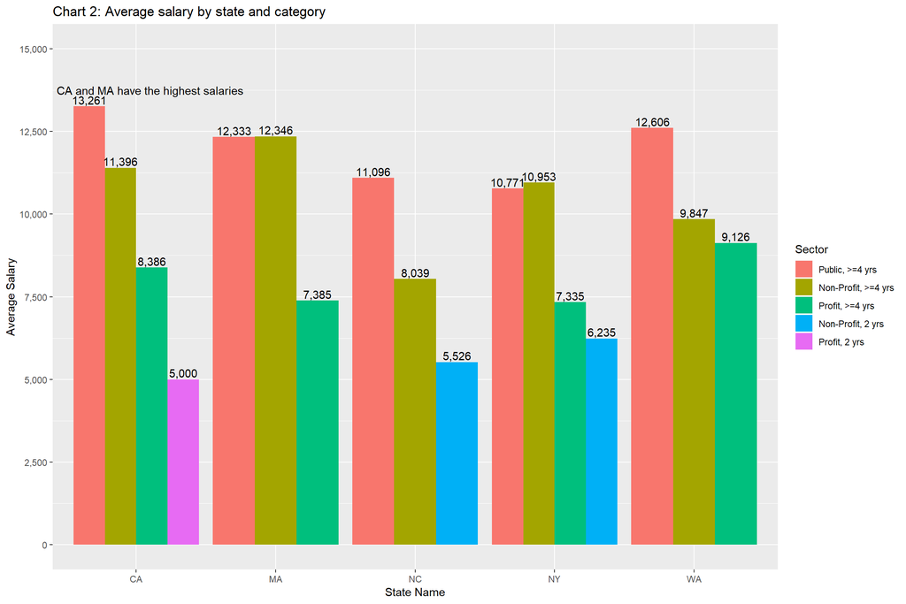

```r
ggplot(sum3, aes(x=STABBR, y=Average_Salaries, fill=SECTOR.f))+
  geom_bar(aes(fill=SECTOR.f), position = "dodge", stat="identity")+
  ggtitle("Chart 2: Average salary by state and category")+
  xlab("State Name")+ylab("Average Salary")+
  geom_text(aes(label = scales::comma(sum3$Average_Salaries)), position=position_dodge(width=0.9), vjust=-0.25)+
  labs(fill="Sector")+
  annotate("text", x = 1.1, y = 13750, label = "CA and MA have the highest salaries")+
  scale_y_continuous(breaks = seq(0,15000, by=2500), limits = c(0,15000), labels = comma)
```

#### Further Analysis of Salary Distribution

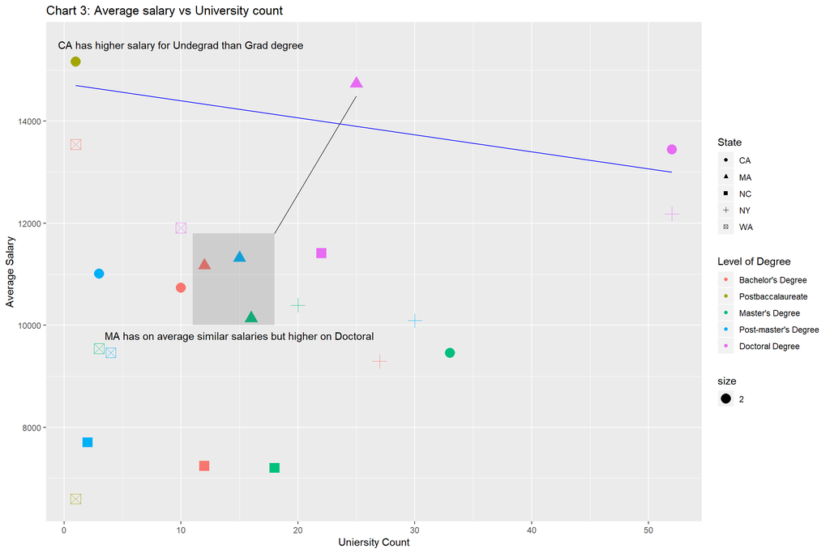

```r
ggplot(sum4, aes(x=Number_of_Universities, y=Average_Salaries, group=STABBR, fill=HLOFFER.f))+
  geom_point(aes(shape=STABBR, color=HLOFFER.f, size=2))+
  ggtitle("Chart 3: Average salary vs University count")+
  xlab("Uniersity Count")+ylab("Average Salary")+
  labs(fill="Level of Degree", color = "Level of Degree")+
  labs(shape="State")+
  annotate("segment", x=1, y=14700, xend=52, yend=13000, color="blue")+
  annotate("text", x =10, y=15500, label="CA has higher salary for Undegrad than Grad degree")+
  annotate("rect", xmin=11, xmax=18, ymin=10000,ymax=11800, alpha=0.2)+
  annotate("segment", x=18,y=11800,xend=25,yend=14500,color="black")+
  annotate("text", x=15, y=9800, label = "MA has on average similar salaries but higher on Doctoral")
```

### References

[^1]: How to use or/and in dplyr to subset a data.frame. Stackoverflow. Link: https://stackoverflow.com/questions/24319747/how-to-use-or-and-in-dplyr-to-subset-a-data-frame
[^2]: FACTOR VARIABLES | R LEARNING MODULES. Institute for Digital Research and Education, UCLA. Link: https://stats.idre.ucla.edu/r/modules/factor-variables/
[^3]: Zhu, Hao. (2019). Create Awesome HTML Table with knitr::kable and kableExtra. GitHub. Link: https://haozhu233.github.io/kableExtra/awesome_table_in_html.html#overview
[^4]: ggplot2 legend : Easy steps to change the position and the appearance of a graph legend in R software. Statistical tools for high-throughput data analysis. Link: http://www.sthda.com/english/wiki/ggplot2-legend-easy-steps-to-change-the-position-and-the-appearance-of-a-graph-legend-in-r-software
[^5]: How to change legend title in ggplot. Stackoverflow. Link: https://stackoverflow.com/questions/14622421/how-to-change-legend-title-in-ggplot
[^6]: How to put labels over geom_bar for each bar in R with ggplot2. Stackoverflow. Link: https://stackoverflow.com/questions/12018499/how-to-put-labels-over-geom-bar-for-each-bar-in-r-with-ggplot2
[^7]: Formatting ggplot2 axis labels with commas (and K? MM?) if I already have a y-scale. Stackoverflow. Link: https://stackoverflow.com/questions/37713351/formatting-ggplot2-axis-labels-with-commas-and-k-mm-if-i-already-have-a-y-sc
[^8]: ggplot2 point shapes. Statistical tools for high-throughput data analysis. Link: http://www.sthda.com/english/wiki/ggplot2-point-shapes
[^9]: Bhaskar VK. hrbrthemes : Additional Themes and Theme Components for ‘ggplot2’. GitHub. Link: https://bhaskarvk.github.io/hrbrthemes/